# AIML_ML_Project_full_code_SaiAdvaithVootukur

## Model Building

### Model Evaluation Criterion

For the criterion we can use to evalute the model, I was debating between Recall and F1 score.

Recall measures the proportion of actual positive cases (customers who did take a loan) that were correctly identified by the model. In this case, this is the percentage of customers who accepted a personal loan that my model correctly predicted would accept a loan. A high recall is important to ensure that I don't miss potential loan customers in my marketing campaign.

On the other hand, F1-score is the harmonic mean of precision and recall. Precision measures the proportion of predicted positive cases (customers my model predicted would take a loan) that were actually positive. A high F1-score indicates a good balance between precision and recall.

Since our objective is to "identify the potential customers who have a higher probability of purchasing the loan" and the bank wants to "expand this base rapidly to bring in more loan business", it is crucial to identify as many potential loan customers as possible. Missing a potential customer (a false negative) means losing a potential loan. While false positives (predicting someone will take a loan when they won't) are not ideal, they are less detrimental than missing a potential customer, as we can adjust your marketing efforts based on the campaign results.

As a result, I believe **Recall** is the most appropriate primary evaluation criterion for this problem because it directly measures the model's ability to identify the customers who are most likely to take out a loan, minimizing the number of missed opportunities. A high recall will help us target the broadest possible set of potential customers for our marketing campaign.

### Model Building

```python
LMTree = DecisionTreeClassifier(random_state=45)
LMTree.fit(X_train, y_train)
```

```
DecisionTreeClassifier(random_state=45)
```

```python
# defining a function to compute different metrics to check performance of a classification model built using sklearn
def model_performance_classification(model, predictors, target):
    """
    Function to compute different metrics to check classification model performance

    model: classifier
    predictors: independent variables
    target: dependent variable
    """

    # predicting using the independent variables
    pred = model.predict(predictors)

    acc = accuracy_score(target, pred)  # to compute Accuracy
    recall = recall_score(target, pred)  # to compute Recall
    precision = precision_score(target, pred)  # to compute Precision
    f1 = f1_score(target, pred)  # to compute F1-score

    # creating a dataframe of metrics
    df_perf = pd.DataFrame(
        {"Accuracy": acc, "Recall": recall, "Precision": precision, "F1": f1,},
        index=[0],
    )

    return df_perf
```

```python
def plot_confusion_matrix(model, predictors, target):
    """
    To plot the confusion_matrix with percentages

    model: classifier
    predictors: independent variables
    target: dependent variable
    """
    # Predict the target values using the provided model and predictors
    y_pred = model.predict(predictors)

    # Compute the confusion matrix comparing the true target values with the predicted values
    cm = confusion_matrix(target, y_pred)

    # Create labels for each cell in the confusion matrix with both count and percentage
    labels = np.asarray(
        [
            ["{0:0.0f}".format(item) + "\n{0:.2%}".format(item / cm.flatten().sum())]
            for item in cm.flatten()
        ]
    ).reshape(2, 2)    # reshaping to a matrix

    # Set the figure size for the plot
    plt.figure(figsize=(6, 4))

    # Plot the confusion matrix as a heatmap with the labels
    sns.heatmap(cm, annot=labels, fmt="")

    # Add a label to the y-axis
    plt.ylabel("True label")

    # Add a label to the x-axis
    plt.xlabel("Predicted label")
```

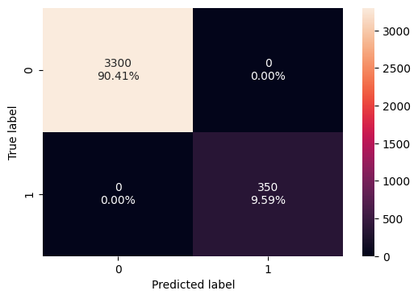

```python
plot_confusion_matrix(LMTree, X_train, y_train)
```

```python
LMTree_train_perf = model_performance_classification(LMTree, X_train, y_train)
LMTree_train_perf
```

|  | Accuracy | Recall | Precision | F1 |
| --- | --- | --- | --- | --- |
| 0 | 1.0 | 1.0 | 1.0 | 1.0 |

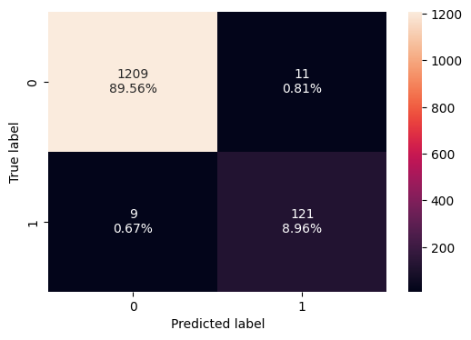

```python
plot_confusion_matrix(LMTree, X_test, y_test)
```

```python
LMTree_test_perf = model_performance_classification(LMTree, X_test, y_test)
LMTree_test_perf
```

|  | Accuracy | Recall | Precision | F1 |
| --- | --- | --- | --- | --- |
| 0 | 0.985185 | 0.930769 | 0.916667 | 0.923664 |

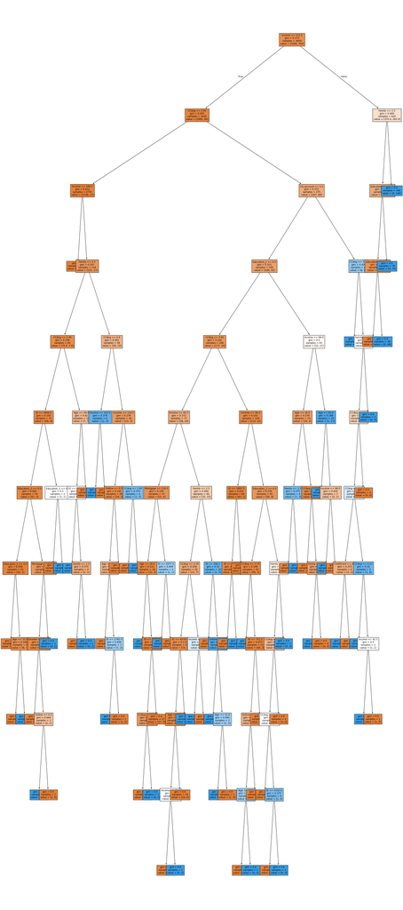

```python
# list of feature names in X_train
feature_names = list(X_train.columns)

# set the figure size for the plot
plt.figure(figsize=(27, 63))

# plotting the decision tree
out = tree.plot_tree(
    LMTree,                         # decision tree classifier model
    feature_names=feature_names,    # list of feature names (columns) in the dataset
    filled=True,                    # fill the nodes with colors based on class
    fontsize=9,                     # font size for the node text
    node_ids=False,                 # do not show the ID of each node
    class_names=None,               # whether or not to display class names
)

# add arrows to the decision tree splits if they are missing
for o in out:
    arrow = o.arrow_patch
    if arrow is not None:
        arrow.set_edgecolor("black")    # set arrow color to black
        arrow.set_linewidth(1)          # set arrow linewidth to 1

# displaying the plot
plt.show()
```

## Model Performance Improvement

### Pre Pruning method

```python
# define the parameters of the tree to iterate over
max_depth_values = np.arange(2, 11, 2)
max_leaf_nodes_values = np.arange(10, 51, 10)
min_samples_split_values = np.arange(10, 51, 10)

# initialize variables to store the best model and its performance
PrePruneLMEstimator = None
PrePruneLMTrainTestDiff = float('inf')

# iterate over all combinations of the specified parameter values
for max_depth in max_depth_values:
    for max_leaf_nodes in max_leaf_nodes_values:
        for min_samples_split in min_samples_split_values:

            # initialize the tree with the current set of parameters
            LMEstimator = DecisionTreeClassifier(max_depth=max_depth, max_leaf_nodes=max_leaf_nodes, min_samples_split=min_samples_split, random_state=45            )

            # fit the model to the training data
            LMEstimator.fit(X_train, y_train)

            # make predictions on the training and test sets
            y_train_pred = LMEstimator.predict(X_train)
            y_test_pred = LMEstimator.predict(X_test)

            # calculate F1 scores for training and test sets
            f1_score_train = f1_score(y_train, y_train_pred)
            f1_score_test = f1_score(y_test, y_test_pred)

            # calculate the absolute difference between training and test F1 scores
            LMTrainTestDiff = abs(f1_score_train - f1_score_test)

            # update the best estimator and best score if the current one has a smaller score difference
            if LMTrainTestDiff < PrePruneLMTrainTestDiff:
                PrePruneLMTrainTestDiff = LMTrainTestDiff
                PrePruneLMEstimator = LMEstimator
```

```python
# creating an instance of the best model
LMPrePrune = PrePruneLMEstimator

# fitting the best model to the training data
LMPrePrune.fit(X_train, y_train)
```

```
DecisionTreeClassifier(max_depth=np.int64(6), max_leaf_nodes=np.int64(20),
                       min_samples_split=np.int64(30), random_state=45)
```

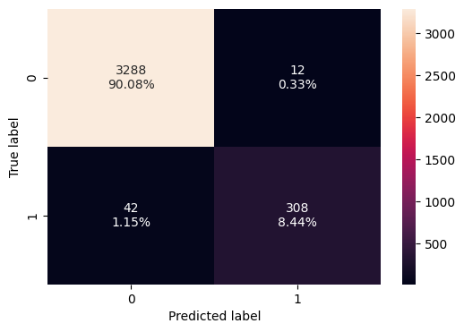

```python
plot_confusion_matrix(LMPrePrune, X_train, y_train)
```

```python
LMPrePrune_train_perf = model_performance_classification(LMPrePrune, X_train, y_train)
LMPrePrune_train_perf
```

|  | Accuracy | Recall | Precision | F1 |
| --- | --- | --- | --- | --- |
| 0 | 0.985205 | 0.88 | 0.9625 | 0.919403 |

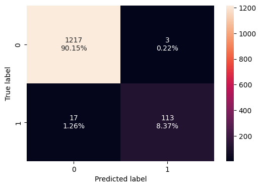

```python
plot_confusion_matrix(LMPrePrune, X_test, y_test)
```

```python
LMPrePrune_test_perf = model_performance_classification(LMPrePrune, X_test, y_test)
LMPrePrune_test_perf
```

|  | Accuracy | Recall | Precision | F1 |
| --- | --- | --- | --- | --- |
| 0 | 0.985185 | 0.869231 | 0.974138 | 0.918699 |

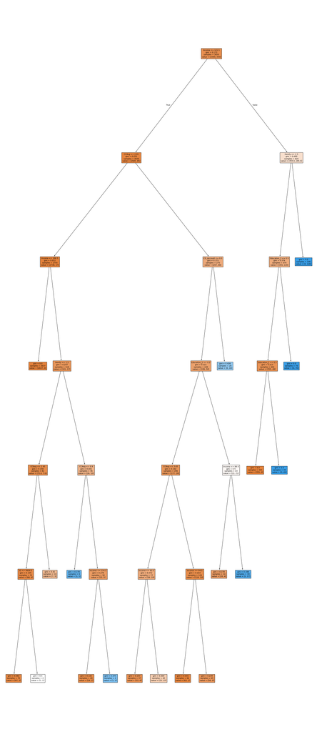

```python
# list of feature names in X_train
feature_names = list(X_train.columns)

# set the figure size for the plot
plt.figure(figsize=(27, 63))

# plotting the decision tree
out = tree.plot_tree(
    LMPrePrune,                     # decision tree classifier model
    feature_names=feature_names,    # list of feature names (columns) in the dataset
    filled=True,                    # fill the nodes with colors based on class
    fontsize=9,                     # font size for the node text
    node_ids=False,                 # do not show the ID of each node
    class_names=None,               # whether or not to display class names
)

# add arrows to the decision tree splits if they are missing
for o in out:
    arrow = o.arrow_patch
    if arrow is not None:
        arrow.set_edgecolor("black")    # set arrow color to black
        arrow.set_linewidth(1)          # set arrow linewidth to 1

# displaying the plot
plt.show()
```

### Post Pruning method

```python
# Create an instance of the decision tree model
LMPostPrune = DecisionTreeClassifier(random_state=45)

# Compute the cost complexity pruning path for the model using the training data
CCPPath = LMPostPrune.cost_complexity_pruning_path(X_train, y_train)

# Extract the array of effective alphas from the pruning path
ccp_alphas = abs(CCPPath.ccp_alphas)

# Extract the array of total impurities at each alpha along the pruning path
impurities = CCPPath.impurities

pd.DataFrame(CCPPath)
```

|  | ccp_alphas | impurities |
| --- | --- | --- |
| 0 | 0.000000 | 0.000000 |
| 1 | 0.000219 | 0.000438 |
| 2 | 0.000244 | 0.000925 |
| 3 | 0.000254 | 0.001434 |
| 4 | 0.000260 | 0.002995 |
| 5 | 0.000260 | 0.003516 |
| 6 | 0.000260 | 0.004037 |
| 7 | 0.000266 | 0.004568 |
| 8 | 0.000270 | 0.005107 |
| 9 | 0.000337 | 0.006119 |
| 10 | 0.000351 | 0.007172 |
| 11 | 0.000360 | 0.008610 |
| 12 | 0.000365 | 0.008975 |
| 13 | 0.000365 | 0.009341 |
| 14 | 0.000384 | 0.010491 |
| 15 | 0.000390 | 0.010881 |
| 16 | 0.000390 | 0.011660 |
| 17 | 0.000411 | 0.012071 |
| 18 | 0.000411 | 0.012482 |
| 19 | 0.000457 | 0.012939 |
| 20 | 0.000468 | 0.013407 |
| 21 | 0.000471 | 0.013878 |
| 22 | 0.000496 | 0.014374 |
| 23 | 0.000500 | 0.014874 |
| 24 | 0.000506 | 0.015380 |
| 25 | 0.000558 | 0.015938 |
| 26 | 0.000605 | 0.017754 |
| 27 | 0.000615 | 0.018369 |
| 28 | 0.000843 | 0.019212 |
| 29 | 0.000861 | 0.020072 |
| 30 | 0.000863 | 0.021798 |
| 31 | 0.000895 | 0.022693 |
| 32 | 0.000955 | 0.027468 |
| 33 | 0.001285 | 0.028753 |
| 34 | 0.002718 | 0.034188 |
| 35 | 0.003116 | 0.037304 |
| 36 | 0.007964 | 0.045269 |
| 37 | 0.023593 | 0.068862 |
| 38 | 0.025242 | 0.094104 |
| 39 | 0.034307 | 0.128411 |
| 40 | 0.044980 | 0.173391 |

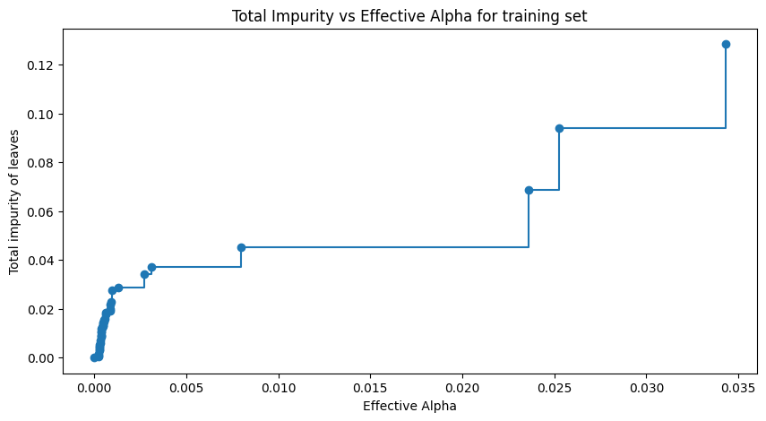

```python
 # Create a figure
fig, ax = plt.subplots(figsize=(10, 5))

# Plot the total impurities versus effective alphas, excluding the last value,
# using markers at each data point and connecting them with steps
ax.plot(ccp_alphas[:-1], impurities[:-1], marker="o", drawstyle="steps-post")

# Set the x-axis label
ax.set_xlabel("Effective Alpha")

# Set the y-axis label
ax.set_ylabel("Total impurity of leaves")

# Set the title of the plot
ax.set_title("Total Impurity vs Effective Alpha for training set");
```

```python
# Initialize an empty list to store the decision tree classifiers
LMPostPruneList = []

# Iterate over each ccp_alpha value extracted from cost complexity pruning path
for ccp_alpha in ccp_alphas:
    # Create an instance of the DecisionTreeClassifier
    LMPostPrune = DecisionTreeClassifier(ccp_alpha=ccp_alpha, random_state=45)

    # Fit the classifier to the training data
    LMPostPrune.fit(X_train, y_train)

    # Append the trained classifier to the list
    LMPostPruneList.append(LMPostPrune)

# Print the number of nodes in the last tree along with its ccp_alpha value
print(
    "Number of nodes in the last tree is {} with ccp_alpha {}".format(
        LMPostPruneList[-1].tree_.node_count, ccp_alphas[-1]
    )
)
```

```
Number of nodes in the last tree is 1 with ccp_alpha 0.044980259531773426
```

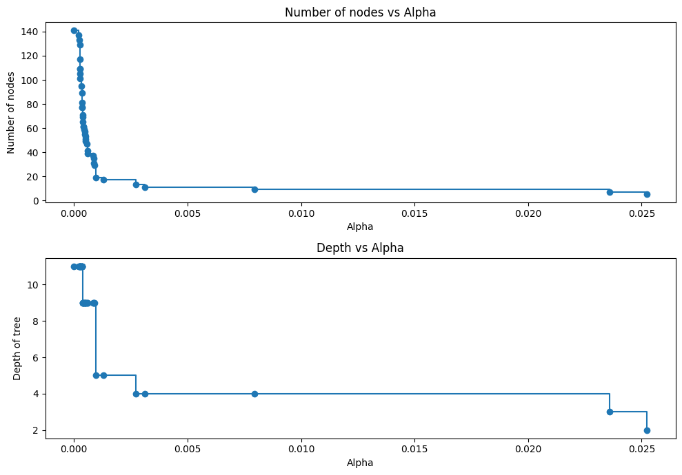

```python
# Remove the last classifier and corresponding ccp_alpha value from the lists
LMPostPruneList = LMPostPruneList[:-1]
ccp_alphas = ccp_alphas[:-1]

# Extract the number of nodes in each tree classifier
LMPostPruneNodes = [LMPostPrune.tree_.node_count for LMPostPrune in LMPostPruneList]

# Extract the maximum depth of each tree classifier
LMPostPruneDepth = [LMPostPrune.tree_.max_depth for LMPostPrune in LMPostPruneList]

# Create a figure and a set of subplots
fig, ax = plt.subplots(2, 1, figsize=(10, 7))

# Plot the number of nodes versus ccp_alphas on the first subplot
ax[0].plot(ccp_alphas, LMPostPruneNodes, marker="o", drawstyle="steps-post")
ax[0].set_xlabel("Alpha")
ax[0].set_ylabel("Number of nodes")
ax[0].set_title("Number of nodes vs Alpha")

# Plot the depth of tree versus ccp_alphas on the second subplot
ax[1].plot(ccp_alphas, LMPostPruneDepth, marker="o", drawstyle="steps-post")
ax[1].set_xlabel("Alpha")
ax[1].set_ylabel("Depth of tree")
ax[1].set_title("Depth vs Alpha")

# Adjust the layout of the subplots to avoid overlap
fig.tight_layout()
```

```python
F1_score_train_PostPrune = []  # Initialize an empty list to store F1 scores for training set for each decision tree classifier

# Iterate through each decision tree classifier in 'clfs'
for LMPostPrune in LMPostPruneList:
    # Predict labels for the training set using the current decision tree classifier
    pred_train = LMPostPrune.predict(X_train)

    # Calculate the F1 score for the training set predictions compared to true labels
    f1_train = f1_score(y_train, pred_train)

    # Append the calculated F1 score to the train_f1_scores list
    F1_score_train_PostPrune.append(f1_train)
```

```python
F1_score_test_PostPrune = []  # Initialize an empty list to store F1 scores for test set for each decision tree classifier

# Iterate through each decision tree classifier in 'clfs'
for LMPostPrune in LMPostPruneList:
    # Predict labels for the test set using the current decision tree classifier
    pred_test = LMPostPrune.predict(X_test)

    # Calculate the F1 score for the test set predictions compared to true labels
    f1_test = f1_score(y_test, pred_test)

    # Append the calculated F1 score to the test_f1_scores list
    F1_score_test_PostPrune.append(f1_test)
```

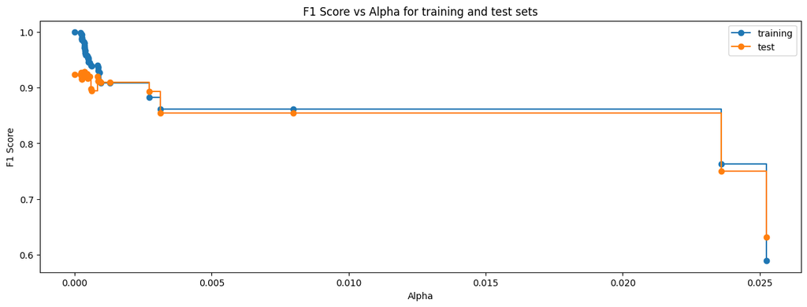

```python
# Create a figure
fig, ax = plt.subplots(figsize=(15, 5))
ax.set_xlabel("Alpha")  # Set the label for the x-axis
ax.set_ylabel("F1 Score")  # Set the label for the y-axis
ax.set_title("F1 Score vs Alpha for training and test sets")  # Set the title of the plot

# Plot the training F1 scores against alpha, using circles as markers and steps-post style
ax.plot(ccp_alphas, F1_score_train_PostPrune, marker="o", label="training", drawstyle="steps-post")

# Plot the testing F1 scores against alpha, using circles as markers and steps-post style
ax.plot(ccp_alphas, F1_score_test_PostPrune, marker="o", label="test", drawstyle="steps-post")

ax.legend();  # Add a legend to the plot
```

```python
# creating the model where we get highest test F1 Score
index_best_model = np.argmax(F1_score_test_PostPrune)

# selcting the decision tree model corresponding to the highest test score
LMPostPruneFinal = LMPostPruneList[index_best_model]
print(LMPostPruneFinal)
```

```
DecisionTreeClassifier(ccp_alpha=np.float64(0.0003595426365222554),
                       random_state=45)
```

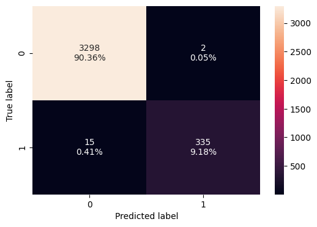

```python
plot_confusion_matrix(LMPostPruneFinal, X_train, y_train)
```

```python
LMPostPruneFinal_train_perf = model_performance_classification(LMPostPruneFinal, X_train, y_train)
LMPostPruneFinal_train_perf
```

|  | Accuracy | Recall | Precision | F1 |
| --- | --- | --- | --- | --- |
| 0 | 0.995342 | 0.957143 | 0.994065 | 0.975255 |

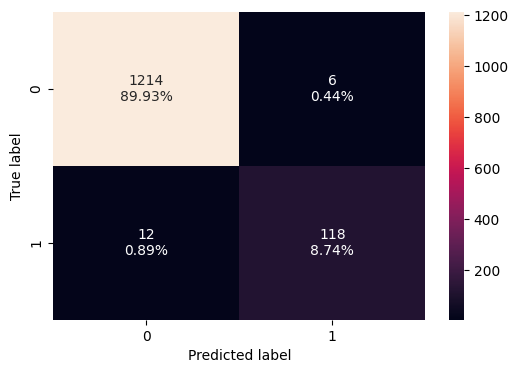

```python
plot_confusion_matrix(LMPostPruneFinal, X_test, y_test)
```

```python
LMPostPruneFinal_test_perf = model_performance_classification(LMPostPruneFinal, X_test, y_test)
LMPostPruneFinal_test_perf
```

|  | Accuracy | Recall | Precision | F1 |
| --- | --- | --- | --- | --- |
| 0 | 0.986667 | 0.907692 | 0.951613 | 0.929134 |

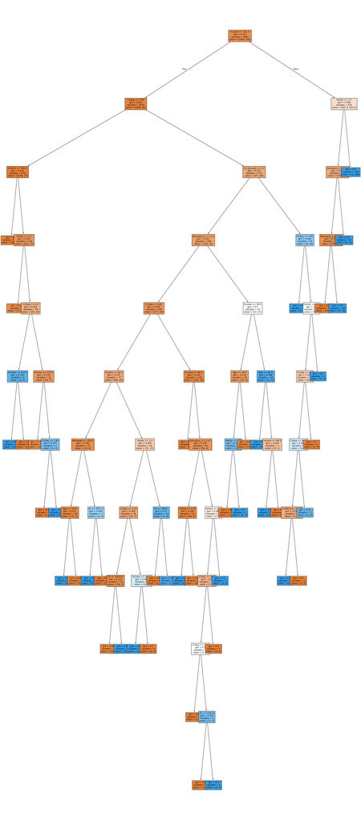

```python
# list of feature names in X_train
feature_names = list(X_train.columns)

# set the figure size for the plot
plt.figure(figsize=(27, 63))

# plotting the decision tree
out = tree.plot_tree(
    LMPostPruneFinal,               # decision tree classifier model
    feature_names=feature_names,    # list of feature names (columns) in the dataset
    filled=True,                    # fill the nodes with colors based on class
    fontsize=9,                     # font size for the node text
    node_ids=False,                 # do not show the ID of each node
    class_names=None,               # whether or not to display class names
)

# add arrows to the decision tree splits if they are missing
for o in out:
    arrow = o.arrow_patch
    if arrow is not None:
        arrow.set_edgecolor("black")    # set arrow color to black
        arrow.set_linewidth(1)          # set arrow linewidth to 1

# displaying the plot
plt.show()
```

## Model Performance Comparison and Final Model Selection

```python
# training performance comparison

models_train_comp_df = pd.concat([LMTree_train_perf.T, LMPrePrune_train_perf.T, LMPostPruneFinal_train_perf.T], axis=1,)
models_train_comp_df.columns = ["Decision Tree (default)", "Decision Tree (Pre-Pruning)", "Decision Tree (Post-Pruning)"]
print("Training performance comparison:")
models_train_comp_df
```

```
Training performance comparison:
```

[output not shown]

```python
# test performance comparison

models_test_comp_df = pd.concat([LMTree_test_perf.T, LMPrePrune_test_perf.T, LMPostPruneFinal_test_perf.T], axis=1,)
models_test_comp_df.columns = ["Decision Tree (default)", "Decision Tree (Pre-Pruning)", "Decision Tree (Post-Pruning)"]
print("Training performance comparison:")
models_test_comp_df
```

```
Training performance comparison:
```

|  | Decision Tree (default) | Decision Tree (Pre-Pruning) | Decision Tree (Post-Pruning) |
| --- | --- | --- | --- |
| Accuracy | 0.985185 | 0.985185 | 0.986667 |
| Recall | 0.930769 | 0.869231 | 0.907692 |
| Precision | 0.916667 | 0.974138 | 0.951613 |
| F1 | 0.923664 | 0.918699 | 0.929134 |

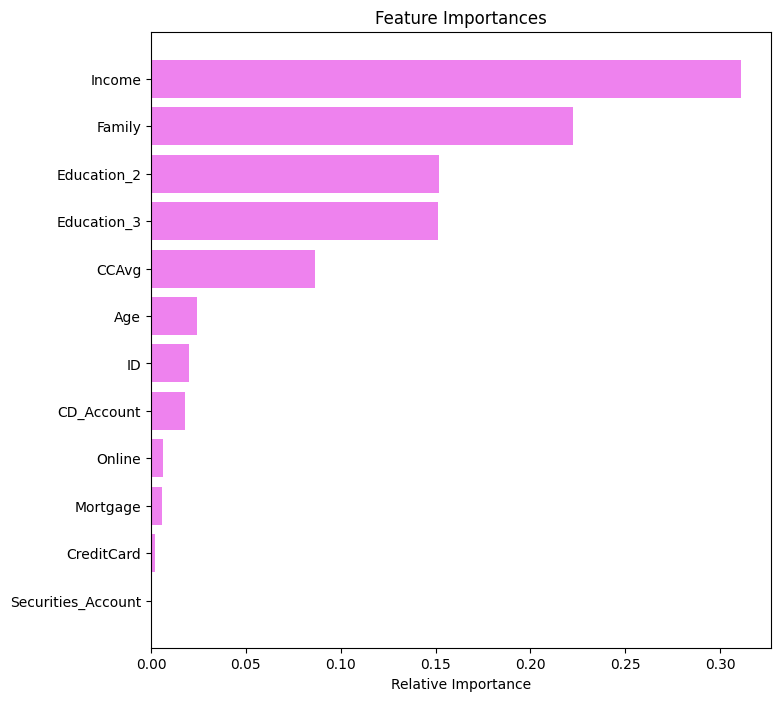

```python
# importance of features in the tree building
importances = LMTree.feature_importances_
indices = np.argsort(importances)

plt.figure(figsize=(8, 8))
plt.title("Feature Importances")
plt.barh(range(len(indices)), importances[indices], color="violet", align="center")
plt.yticks(range(len(indices)), [feature_names[i] for i in indices])
plt.xlabel("Relative Importance")
plt.show()
```

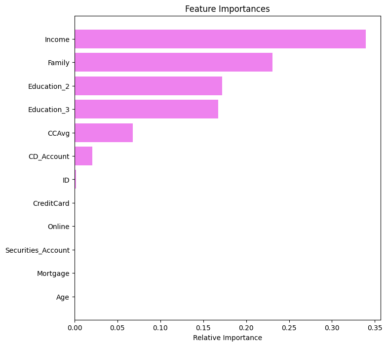

```python
# importance of features in the tree building
importances = LMPrePrune.feature_importances_
indices = np.argsort(importances)

plt.figure(figsize=(8, 8))
plt.title("Feature Importances")
plt.barh(range(len(indices)), importances[indices], color="violet", align="center")
plt.yticks(range(len(indices)), [feature_names[i] for i in indices])
plt.xlabel("Relative Importance")
plt.show()
```

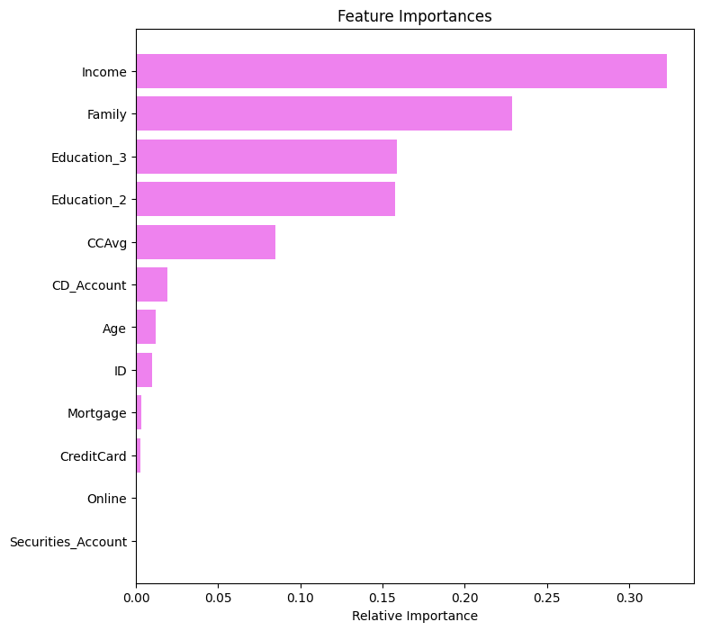

```python
# importance of features in the tree building
importances = LMPostPruneFinal.feature_importances_
indices = np.argsort(importances)

plt.figure(figsize=(8, 8))
plt.title("Feature Importances")
plt.barh(range(len(indices)), importances[indices], color="violet", align="center")
plt.yticks(range(len(indices)), [feature_names[i] for i in indices])
plt.xlabel("Relative Importance")
plt.show()
```

```python
%%time
# choosing a data point
applicant_details = X_test.iloc[11:12, :]

# making a prediction
approval_prediction = LMTree.predict(applicant_details)

print(approval_prediction)
```

```
[1]
CPU times: user 5.22 ms, sys: 0 ns, total: 5.22 ms
Wall time: 10.1 ms
```

```python
%%time
# choosing a data point
applicant_details = X_test.iloc[11:12, :]

# making a prediction
approval_prediction = LMPrePrune.predict(applicant_details)

print(approval_prediction)
```

```
[1]
CPU times: user 4.43 ms, sys: 0 ns, total: 4.43 ms
Wall time: 6.81 ms
```

```python
%%time
# choosing a data point
applicant_details = X_test.iloc[11:12, :]

# making a prediction
approval_prediction = LMPostPruneFinal.predict(applicant_details)

print(approval_prediction)
```

```
[1]
CPU times: user 2.58 ms, sys: 1.07 ms, total: 3.66 ms
Wall time: 3.45 ms
```

```python
# making a prediction
approval_likelihood = LMTree.predict_proba(applicant_details)

print(approval_likelihood[0, 1])
```

```
1.0
```

```python
# making a prediction
approval_likelihood = LMPrePrune.predict_proba(applicant_details)

print(approval_likelihood[0, 1])
```

```
0.8947368421052632
```

```python
# making a prediction
approval_likelihood = LMPostPruneFinal.predict_proba(applicant_details)

print(approval_likelihood[0, 1])
```

```
1.0
```

## Final Model Selection

After taking a look at all the models here, here are some conclusions we can make:

1. Default Decision Tree: Achieves perfect scores (Accuracy, Recall, Precision, F1) on the training data, indicating it has likely overfit to the training set. This is a common issue with unpruned decision trees. Its test set performance, while still high, shows a drop in all metrics compared to the training set, confirming the overfitting. However, it has the highest Recall score on the test set among the three models.
2. Pre-Pruned Decision Tree: This model shows good performance on both training and test sets, with a smaller difference in metrics compared to the default tree, suggesting less overfitting. Its Recall on the test set is lower than the default tree but its Precision is higher. This is also the simplest tree we have based on the parameters set (max_depth, max_leaf_nodes, min_samples_split).
3. Post-Pruned Decision Tree: This model also shows good performance and a better balance between training and test scores than the default tree. Its Recall on the test set is better than the pre-pruned tree and closer to the default tree, while maintaining a high Precision.

When we compare all 3 models based on our evaluation criterion (Recall):

1. The Default Decision Tree has the highest Recall on the test set (0.930769). This means it is the best at identifying actual loan customers.
2. The Post-Pruned Decision Tree has the second highest Recall on the test set (0.907692), which is very close to the default tree, and it also has a higher Precision and F1-score on the test set compared to the default tree.
3. The Pre-Pruned Decision Tree has the lowest Recall on the test set (0.869231) among the three models.

Since our objective is to identify as many potential loan customers, this means we want a good recall. While the default tree has the highest test recall, its perfect training performance indicates significant overfitting, which might make it less reliable on completely unseen data in the future.

On the other hand, the post-pruned tree offers a good balance. It has a high test recall that is very close to the default tree, but with better generalization (less overfitting) as seen in the comparison of training and test scores. It also has higher precision, meaning a larger proportion of its positive predictions are correct. This is valuable as it reduces the effort spent on marketing to customers who are not likely to take a loan.

As a result, the Post-Pruned Decision Tree is likely the most suitable model due to its high test recall and better balance between training and test performance compared to the default tree. Additionally, we can see that Income, CCAvg, Family, and Education are the most important factors in determining whether a customer will accept a personal loan.

## Actionable Insights and Business Recommendations

- What recommedations would you suggest to the bank?

For recommendations we can make to the business:

1. Develop Targeted Marketing Campaigns: Focus marketing efforts for personal loans on existing liability customers who have high incomes and high credit card spending. Utilize the model to identify and segment these customers for personalized offers and communications.
2. Tailor Loan Products and Offers: Consider creating or promoting personal loan products that are particularly attractive to customers with characteristics identified as high-likelihood borrowers (e.g., higher loan amounts for high-income customers, flexible repayment options).
3. Leverage Customer Data: Use existing customer data on income, credit card spending, family size, and education to build a prioritized list of potential loan customers.
4. Integrate with Digital Channels: For customers who use online banking, consider targeted digital advertisements or personalized offers within the online banking platform.
5. Monitor and Refine: Continuously monitor the performance of your marketing campaigns and the model's predictions. Use the results to refine your targeting strategies and potentially update the model over time as more data becomes available.
6. Further Explore Family Size and Education Segments: Conduct deeper analysis into how different family sizes and education levels interact with other factors to influence loan acceptance. This could lead to even more granular targeting strategies.

```python
#@title Convert ipynb to HTML in Colab
# Upload ipynb
from google.colab import files
f = files.upload()

# Convert ipynb to html
import subprocess
file0 = list(f.keys())[0]
_ = subprocess.run(["pip", "install", "nbconvert"])
_ = subprocess.run(["jupyter", "nbconvert", file0, "--to", "html"])

# download the html
files.download(file0[:-5]+"html")
```